#Introduction

It is now possible to collect a large amount of data about personal movement using activity monitoring devices such as a Fitbit, Nike Fuelband, or Jawbone Up. These type of devices are part of the “quantified self” movement – a group of enthusiasts who take measurements about themselves regularly to improve their health, to find patterns in their behavior, or because they are tech geeks. But these data remain under-utilized both because the raw data are hard to obtain and there is a lack of statistical methods and software for processing and interpreting the data.

This assignment makes use of data from a personal activity monitoring device. This device collects data at 5 minute intervals through out the day. The data consists of two months of data from an anonymous individual collected during the months of October and November, 2012 and include the number of steps taken in 5 minute intervals each day.

## Loading and preprocessing the data

```r
library(ggplot2)
library(dplyr)
activity <- data.table::fread(input = "/Users/eshanchatty/Downloads/activity.csv")
dim(activity)
```

```
## [1] 17568     3
```

```r
names(activity)
```

```
## [1] "steps"    "date"     "interval"
```

```r
head(activity)
```

```
##    steps       date interval
## 1:    NA 2012-10-01        0
## 2:    NA 2012-10-01        5
## 3:    NA 2012-10-01       10
## 4:    NA 2012-10-01       15
## 5:    NA 2012-10-01       20
## 6:    NA 2012-10-01       25
```

```r
str(activity)
```

```
## Classes 'data.table' and 'data.frame':   17568 obs. of  3 variables:
##  $ steps   : int  NA NA NA NA NA NA NA NA NA NA ...
##  $ date    : chr  "2012-10-01" "2012-10-01" "2012-10-01" "2012-10-01" ...
##  $ interval: int  0 5 10 15 20 25 30 35 40 45 ...
##  - attr(*, ".internal.selfref")=<externalptr>
```

```r
##To check the number of NA or missing values in the steps Variable.
sum(is.na(activity$steps))
```

```
## [1] 2304
```

```r
## transforming the date column into date format using lubridate
library(lubridate)
activity$date<-ymd(activity$date)
length(unique(activity$date))
```

```
## [1] 61
```

## What is mean and median total number of steps taken per day?

```r
Total_Steps <- activity[, c(lapply(.SD, sum, na.rm = FALSE)), .SDcols = c("steps"), by = .(date)]
head(Total_Steps)
```

```
##          date steps
## 1: 2012-10-01    NA
## 2: 2012-10-02   126
## 3: 2012-10-03 11352
## 4: 2012-10-04 12116
## 5: 2012-10-05 13294
## 6: 2012-10-06 15420
```

```r
mean(Total_Steps$steps,na.rm = TRUE)
```

```
## [1] 10766.19
```

```r
median(Total_Steps$steps,na.rm = TRUE)
```

```
## [1] 10765
```

## Histogram of the total number of steps taken each day?

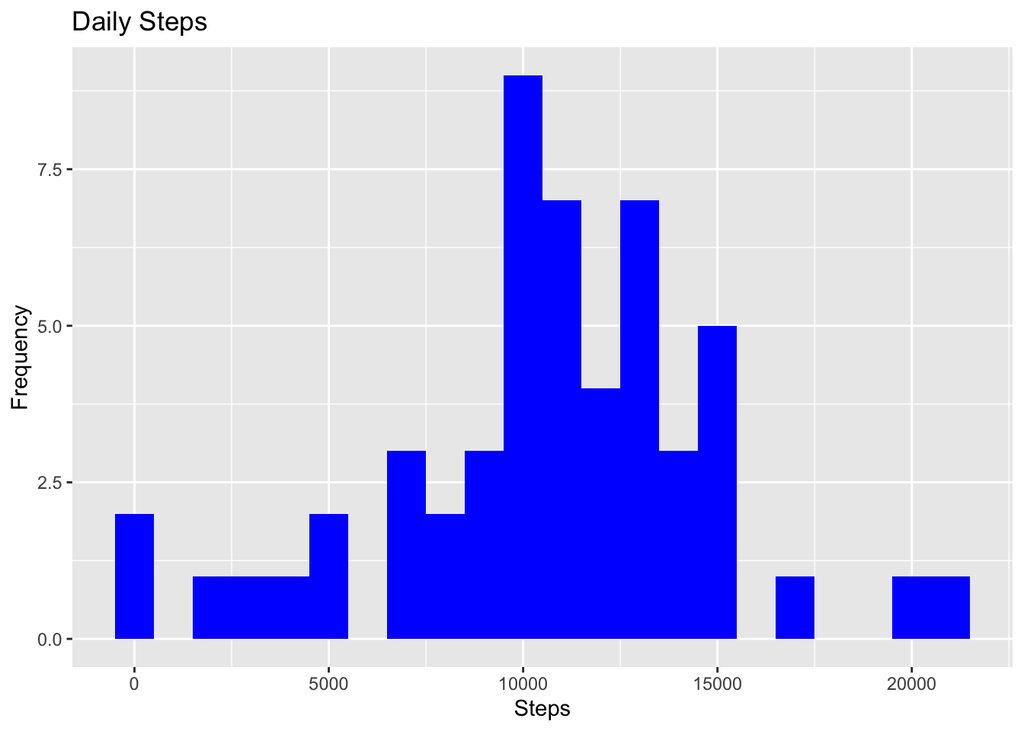

```r
ggplot(Total_Steps, aes(x = steps)) +
    geom_histogram(fill = "blue", binwidth = 1000) +
    labs(title = "Daily Steps", x = "Steps", y = "Frequency")
```

## Time series plot of the average number of steps taken?

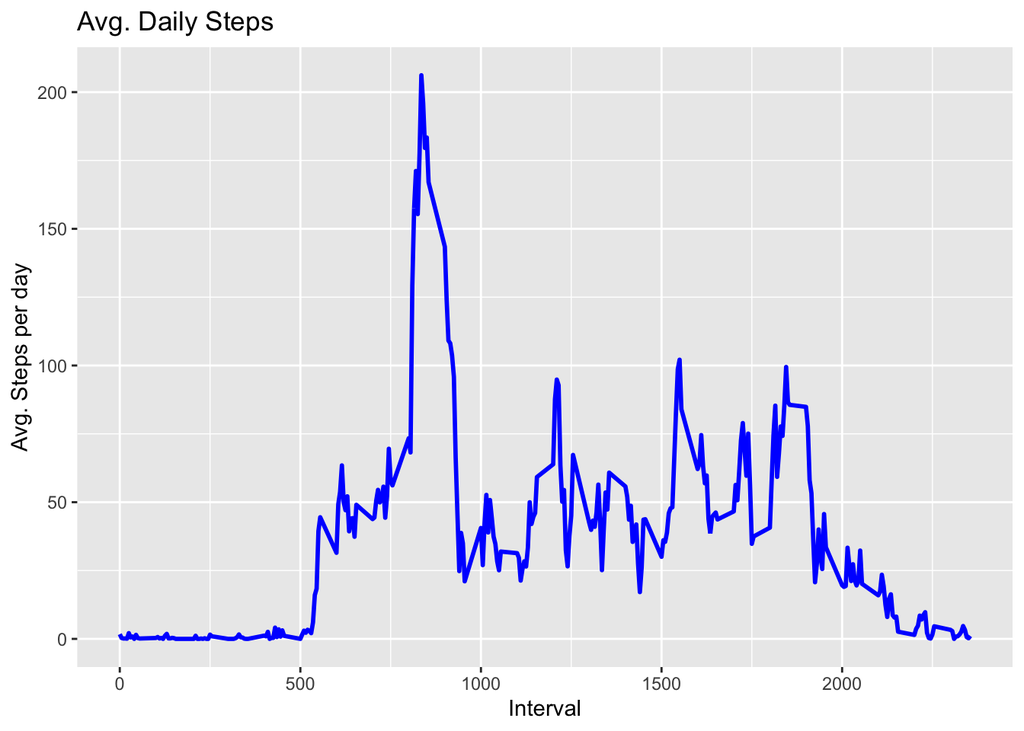

```r
Avgpattern <- activity[, c(lapply(.SD, mean, na.rm = TRUE)), .SDcols = c("steps"), by = .(interval)]

ggplot(Avgpattern, aes(x = interval , y = steps)) + geom_line(color="blue", size=1) + labs(title = "Avg. Daily Steps", x = "Interval", y = "Avg. Steps per day")
```

```r
activity$interval<-factor(activity$interval)
Q5<-aggregate(data=activity,steps~date+interval,FUN="mean")
Q5<-aggregate(data=Q5,steps~interval,FUN="max")
```

## Imputing missing values

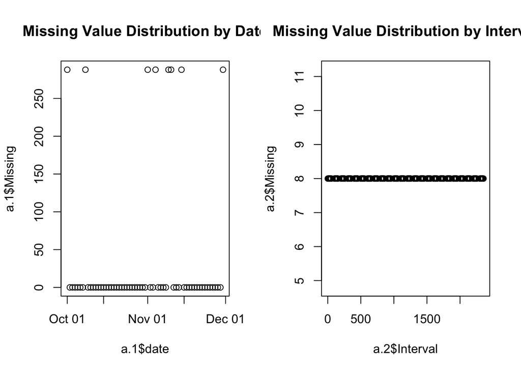

```r
a<-activity
a$Missing<-is.na(a$steps)
a<-aggregate(data=a,Missing~date+interval,FUN="sum")
a.1<-data.frame(tapply(a$Missing,a$date,sum))
a.1$date<-rownames(a.1)
rownames(a.1)<-NULL
names(a.1)<-c("Missing","date")
a.1$date<-as.Date(a.1$date,format="%Y-%m-%d")
a.2<-data.frame(tapply(a$Missing,a$interval,sum))
a.2$date<-rownames(a.2)
rownames(a.2)<-NULL
names(a.2)<-c("Missing","Interval")
par(mfrow=c(1,2))
plot(y=a.1$Missing,x=a.1$date,main="Missing Value Distribution by Date")
plot(y=a.2$Missing,x=a.2$Interval,main="Missing Value Distribution by Interval")
```

```r
table(activity$date)
```

```
##
## 2012-10-01 2012-10-02 2012-10-03 2012-10-04 2012-10-05 2012-10-06 2012-10-07
##        288        288        288        288        288        288        288
## 2012-10-08 2012-10-09 2012-10-10 2012-10-11 2012-10-12 2012-10-13 2012-10-14
##        288        288        288        288        288        288        288
## 2012-10-15 2012-10-16 2012-10-17 2012-10-18 2012-10-19 2012-10-20 2012-10-21
##        288        288        288        288        288        288        288
## 2012-10-22 2012-10-23 2012-10-24 2012-10-25 2012-10-26 2012-10-27 2012-10-28
##        288        288        288        288        288        288        288
## 2012-10-29 2012-10-30 2012-10-31 2012-11-01 2012-11-02 2012-11-03 2012-11-04
##        288        288        288        288        288        288        288
## 2012-11-05 2012-11-06 2012-11-07 2012-11-08 2012-11-09 2012-11-10 2012-11-11
##        288        288        288        288        288        288        288
## 2012-11-12 2012-11-13 2012-11-14 2012-11-15 2012-11-16 2012-11-17 2012-11-18
##        288        288        288        288        288        288        288
## 2012-11-19 2012-11-20 2012-11-21 2012-11-22 2012-11-23 2012-11-24 2012-11-25
##        288        288        288        288        288        288        288
## 2012-11-26 2012-11-27 2012-11-28 2012-11-29 2012-11-30
##        288        288        288        288        288
```

By this point, from the plot, that the missing values have a very disctinct pattern. For every interval, there are consistantly 8 missing values. For the date, there are consistantly 288 missing values. And in total, there are 8 dates that have missing value. We don’t exactly know the cause for these missing values but there’s a pattern. For that matter, we can see that the mean value imputation is appropriate.

We can see that every date has 288 data points. It means that the 8 dates have no data points at all what so ever. We can refine the analysis by looking at these missing values depending on their Weekday and interval parameters to matach with the average

```r
#Dates that have missing values
library(lubridate)
a.3<-as.data.frame(a.1) %>% select(date,Missing) %>% arrange(desc(Missing))
a.3<-a.3[which(a.3$Missing!=0),]
a.3$Weekday<-wday(a.3$date,label=TRUE)
a.4<-activity
a.4$weekday<-wday(a.4$date,label=TRUE)
#Finding the mean of steps every monday, and every interval
a.5<-aggregate(data=a.4,steps~interval+weekday,FUN="mean",na.rm=TRUE)
#Merge the pre-imputation table a.4 table with the average table a.5
a.6<-merge(x=a.4,y=a.5,by.x=c("interval","weekday"),by.y=c("interval","weekday"),all.x=TRUE)
#Conditionally replacing the steps.x column NA value with the values from steps.y column value
a.6$Steps.Updated<-0
for (i in 1:dim(a.6)[[1]]){
if(is.na(a.6[i,3])){a.6[i,6]=a.6[i,5]}
else {a.6[i,6]=a.6[i,3]}
}
#Now simplify the imputed analytical data frame
a.6 <-a.6  %>% select(date,weekday,interval,Steps.Updated)
names(a.6)[[4]]<-"Steps"
```

## Step 7

```r
png("plot7.png")
qplot(a.6$Steps,geom="histogram",main="Total steps taken histogram post imputation",xlab="Steps",ylab="Count")
dev.off()
```

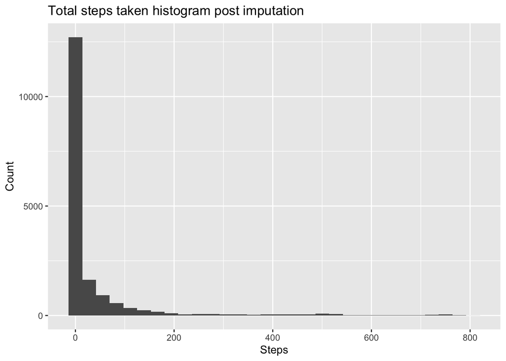

```r
qplot(a.6$Steps,geom="histogram",main="Total steps taken histogram post imputation",xlab="Steps",ylab="Count")
```

## Step 8

Panel plot comparing the average number of steps taken per 5-minute interval across weekdays and weekends

```
## geom_path: Each group consists of only one observation. Do you need to adjust
## the group aesthetic?
## geom_path: Each group consists of only one observation. Do you need to adjust
## the group aesthetic?
```

[figure not shown]

```r
activity[, date := as.POSIXct(date, format = "%Y-%m-%d")]
activity[, `Day of Week`:= weekdays(x = date)]
activity[grepl(pattern = "Monday|Tuesday|Wednesday|Thursday|Friday", x = `Day of Week`), "weekday or weekend"] <- "weekday"
activity[grepl(pattern = "Saturday|Sunday", x = `Day of Week`), "weekday or weekend"] <- "weekend"
activity[,`weekday or weekend` := as.factor(`weekday or weekend`)]
activity[is.na(steps), "steps"] <- activity[, c(lapply(.SD, median, na.rm = TRUE)), .SDcols = c("steps")]
Interval <- activity[, c(lapply(.SD, mean, na.rm = TRUE)), .SDcols = c("steps"), by = .(interval, `weekday or weekend`)]

ggplot(Interval , aes(x = interval , y = steps, color=`weekday or weekend`)) + geom_line() + labs(title = "Avg. Daily Steps by Weektype", x = "Interval", y = "No. of Steps") + facet_wrap(~`weekday or weekend` , ncol = 1, nrow=2)
```